# BankChurnPrediction_Project

```python
import pandas as pd
import numpy as np
import seaborn as sns
import matplotlib.pyplot as plt
pd.options.display.float_format = '{:,.4f}'.format
%matplotlib inline

from sklearn.model_selection import train_test_split
from sklearn.preprocessing import StandardScaler, LabelEncoder
from sklearn import metrics
from sklearn.metrics import confusion_matrix

import tensorflow as tf
from tensorflow.keras import Sequential
from tensorflow.keras.layers import Dense
```

**1. Read the dataset**

```python
from google.colab import drive
drive.mount('/content/drive')
```

```python
project_path = '/content/drive/My Drive/Colab Notebooks/6_IntroductiontoNeuralNetworks/'
```

```python
dataset_file = project_path + 'bank.csv'
```

```python
data = pd.read_csv(dataset_file)
```

```python
data.head()
```

|  | RowNumber | CustomerId | Surname | CreditScore | Geography | Gender | Age | Tenure | Balance | NumOfProducts | HasCrCard | IsActiveMember | EstimatedSalary | Exited |
| --- | --- | --- | --- | --- | --- | --- | --- | --- | --- | --- | --- | --- | --- | --- |
| 0 | 1 | 15634602 | Hargrave | 619 | France | Female | 42 | 2 | 0.0000 | 1 | 1 | 1 | 101,348.8800 | 1 |
| 1 | 2 | 15647311 | Hill | 608 | Spain | Female | 41 | 1 | 83,807.8600 | 1 | 0 | 1 | 112,542.5800 | 0 |
| 2 | 3 | 15619304 | Onio | 502 | France | Female | 42 | 8 | 159,660.8000 | 3 | 1 | 0 | 113,931.5700 | 1 |
| 3 | 4 | 15701354 | Boni | 699 | France | Female | 39 | 1 | 0.0000 | 2 | 0 | 0 | 93,826.6300 | 0 |
| 4 | 5 | 15737888 | Mitchell | 850 | Spain | Female | 43 | 2 | 125,510.8200 | 1 | 1 | 1 | 79,084.1000 | 0 |

```python
data.info()
```

```
<class 'pandas.core.frame.DataFrame'>
RangeIndex: 10000 entries, 0 to 9999
Data columns (total 14 columns):
 #   Column           Non-Null Count  Dtype
---  ------           --------------  -----
 0   RowNumber        10000 non-null  int64
 1   CustomerId       10000 non-null  int64
 2   Surname          10000 non-null  object
 3   CreditScore      10000 non-null  int64
 4   Geography        10000 non-null  object
 5   Gender           10000 non-null  object
 6   Age              10000 non-null  int64
 7   Tenure           10000 non-null  int64
 8   Balance          10000 non-null  float64
 9   NumOfProducts    10000 non-null  int64
 10  HasCrCard        10000 non-null  int64
 11  IsActiveMember   10000 non-null  int64
 12  EstimatedSalary  10000 non-null  float64
 13  Exited           10000 non-null  int64
dtypes: float64(2), int64(9), object(3)
memory usage: 1.1+ MB
```

```python
data.describe()
```

|  | RowNumber | CustomerId | CreditScore | Age | Tenure | Balance | NumOfProducts | HasCrCard | IsActiveMember | EstimatedSalary | Exited |
| --- | --- | --- | --- | --- | --- | --- | --- | --- | --- | --- | --- |
| count | 10,000.0000 | 10,000.0000 | 10,000.0000 | 10,000.0000 | 10,000.0000 | 10,000.0000 | 10,000.0000 | 10,000.0000 | 10,000.0000 | 10,000.0000 | 10,000.0000 |
| mean | 5,000.5000 | 15,690,940.5694 | 650.5288 | 38.9218 | 5.0128 | 76,485.8893 | 1.5302 | 0.7055 | 0.5151 | 100,090.2399 | 0.2037 |
| std | 2,886.8957 | 71,936.1861 | 96.6533 | 10.4878 | 2.8922 | 62,397.4052 | 0.5817 | 0.4558 | 0.4998 | 57,510.4928 | 0.4028 |
| min | 1.0000 | 15,565,701.0000 | 350.0000 | 18.0000 | 0.0000 | 0.0000 | 1.0000 | 0.0000 | 0.0000 | 11.5800 | 0.0000 |
| 25% | 2,500.7500 | 15,628,528.2500 | 584.0000 | 32.0000 | 3.0000 | 0.0000 | 1.0000 | 0.0000 | 0.0000 | 51,002.1100 | 0.0000 |
| 50% | 5,000.5000 | 15,690,738.0000 | 652.0000 | 37.0000 | 5.0000 | 97,198.5400 | 1.0000 | 1.0000 | 1.0000 | 100,193.9150 | 0.0000 |
| 75% | 7,500.2500 | 15,753,233.7500 | 718.0000 | 44.0000 | 7.0000 | 127,644.2400 | 2.0000 | 1.0000 | 1.0000 | 149,388.2475 | 0.0000 |
| max | 10,000.0000 | 15,815,690.0000 | 850.0000 | 92.0000 | 10.0000 | 250,898.0900 | 4.0000 | 1.0000 | 1.0000 | 199,992.4800 | 1.0000 |

```python
data.shape
```

```
(10000, 14)
```

There are 14 features and 10000 datapoints. There doesn't seem to be any NULL value for any of the features

While most of the features seem to be CONTINUOUS data, the fact is features like NumOfProducts, HasCrCard, IsActiveMember is actually CATEGORICAL in nature although they are shown to be of numerical & continuous type

Some features like SURNAME, GEOGRAPHY, GENDER are outright CATEGORICAL in nature & shown to be of OBJECT type

**2. Drop the columns which are unique for all users like IDs**

```python
print ("Unique values for Surname: ",data['Surname'].nunique())
print ("Unique values for Geography: ",data['Geography'].nunique())
print ("Unique values for Gender: ",data['Gender'].nunique())
```

```
Unique values for Surname:  2932
Unique values for Geography:  3
Unique values for Gender:  2
```

```python
data['Geography'].value_counts()
```

```
France     5014
Germany    2509
Spain      2477
Name: Geography, dtype: int64
```

```python
data['Exited'].value_counts()
```

```
0    7963
1    2037
Name: Exited, dtype: int64
```

There are 3 distinct values for GEOGRAPHY & 2 distinct values for GENDER. We can substitute the same with dummy encoded values. For SURNAME, it will be better to drop the same as there doesn't seem to be much correlation between someones SURNAME & whether he/she continues business with the Bank

```python
data_bkp = data.copy()
data = data.drop(['RowNumber', 'CustomerId', 'Surname'], axis=1)
```

```python
data.describe().T
```

|  | count | mean | std | min | 25% | 50% | 75% | max |
| --- | --- | --- | --- | --- | --- | --- | --- | --- |
| CreditScore | 10,000.0000 | 650.5288 | 96.6533 | 350.0000 | 584.0000 | 652.0000 | 718.0000 | 850.0000 |
| Age | 10,000.0000 | 38.9218 | 10.4878 | 18.0000 | 32.0000 | 37.0000 | 44.0000 | 92.0000 |
| Tenure | 10,000.0000 | 5.0128 | 2.8922 | 0.0000 | 3.0000 | 5.0000 | 7.0000 | 10.0000 |
| Balance | 10,000.0000 | 76,485.8893 | 62,397.4052 | 0.0000 | 0.0000 | 97,198.5400 | 127,644.2400 | 250,898.0900 |
| NumOfProducts | 10,000.0000 | 1.5302 | 0.5817 | 1.0000 | 1.0000 | 1.0000 | 2.0000 | 4.0000 |
| HasCrCard | 10,000.0000 | 0.7055 | 0.4558 | 0.0000 | 0.0000 | 1.0000 | 1.0000 | 1.0000 |
| IsActiveMember | 10,000.0000 | 0.5151 | 0.4998 | 0.0000 | 0.0000 | 1.0000 | 1.0000 | 1.0000 |
| EstimatedSalary | 10,000.0000 | 100,090.2399 | 57,510.4928 | 11.5800 | 51,002.1100 | 100,193.9150 | 149,388.2475 | 199,992.4800 |
| Exited | 10,000.0000 | 0.2037 | 0.4028 | 0.0000 | 0.0000 | 0.0000 | 0.0000 | 1.0000 |

**3. Perform bivariate analysis and give your insights from the same**

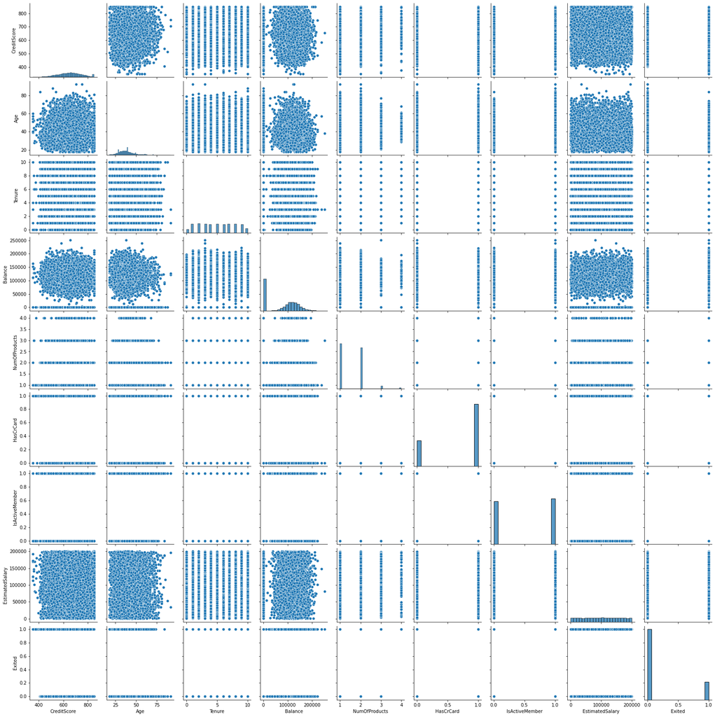

```python
sns.pairplot(data)
```

```python
data.corr()
```

|  | CreditScore | Age | Tenure | Balance | NumOfProducts | HasCrCard | IsActiveMember | EstimatedSalary | Exited |
| --- | --- | --- | --- | --- | --- | --- | --- | --- | --- |
| CreditScore | 1.0000 | -0.0040 | 0.0008 | 0.0063 | 0.0122 | -0.0055 | 0.0257 | -0.0014 | -0.0271 |
| Age | -0.0040 | 1.0000 | -0.0100 | 0.0283 | -0.0307 | -0.0117 | 0.0855 | -0.0072 | 0.2853 |
| Tenure | 0.0008 | -0.0100 | 1.0000 | -0.0123 | 0.0134 | 0.0226 | -0.0284 | 0.0078 | -0.0140 |
| Balance | 0.0063 | 0.0283 | -0.0123 | 1.0000 | -0.3042 | -0.0149 | -0.0101 | 0.0128 | 0.1185 |
| NumOfProducts | 0.0122 | -0.0307 | 0.0134 | -0.3042 | 1.0000 | 0.0032 | 0.0096 | 0.0142 | -0.0478 |
| HasCrCard | -0.0055 | -0.0117 | 0.0226 | -0.0149 | 0.0032 | 1.0000 | -0.0119 | -0.0099 | -0.0071 |
| IsActiveMember | 0.0257 | 0.0855 | -0.0284 | -0.0101 | 0.0096 | -0.0119 | 1.0000 | -0.0114 | -0.1561 |
| EstimatedSalary | -0.0014 | -0.0072 | 0.0078 | 0.0128 | 0.0142 | -0.0099 | -0.0114 | 1.0000 | 0.0121 |
| Exited | -0.0271 | 0.2853 | -0.0140 | 0.1185 | -0.0478 | -0.0071 | -0.1561 | 0.0121 | 1.0000 |

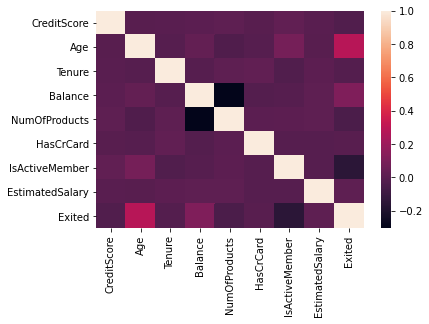

```python
sns.heatmap(data.corr())
```

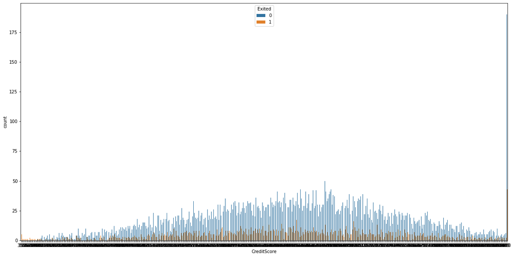

```python
plt.figure(figsize=(20,10))
sns.countplot(x=data['CreditScore'],hue=data['Exited'])
```

There doesn't seem to be much correlation between CreditScore & whether a customer stays with the Bank or not

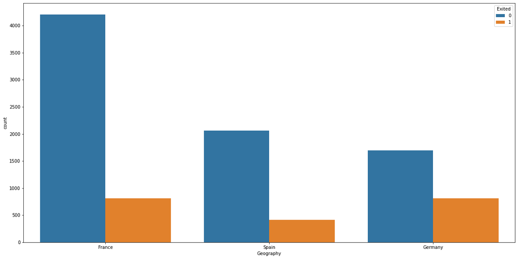

```python
plt.figure(figsize=(20,10))
sns.countplot(x=data['Geography'],hue=data['Exited'])
```

As we have seen earlier, majority of the Bank's customers are from FRANCE, while SPAIN & GERMANY have comparable number of customers.

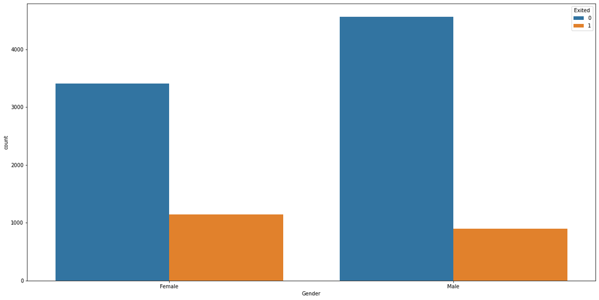

```python
plt.figure(figsize=(20,10))
sns.countplot(x=data['Gender'],hue=data['Exited'])
```

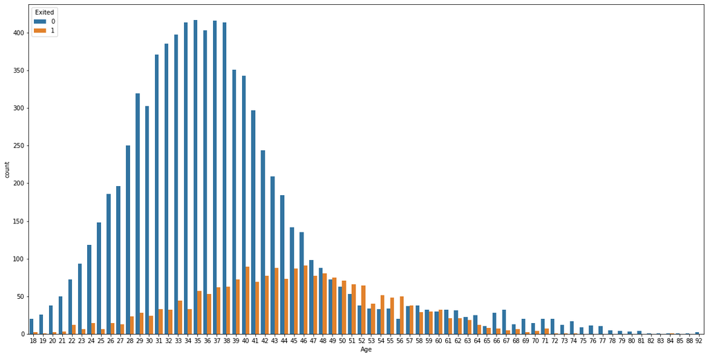

```python
plt.figure(figsize=(20,10))
sns.countplot(x=data['Age'],hue=data['Exited'])
```

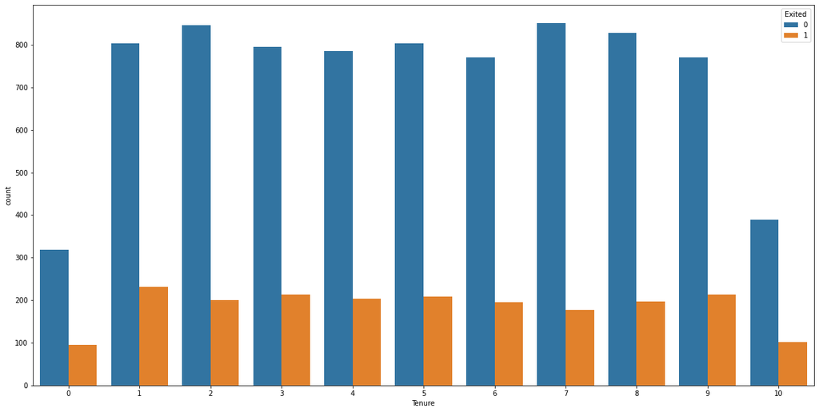

```python
plt.figure(figsize=(20,10))
sns.countplot(x=data['Tenure'],hue=data['Exited'])
```

There doesn't seem to be much correlation between the TENURE a customer has stayed invested in the Bank & whether he/she has still quit

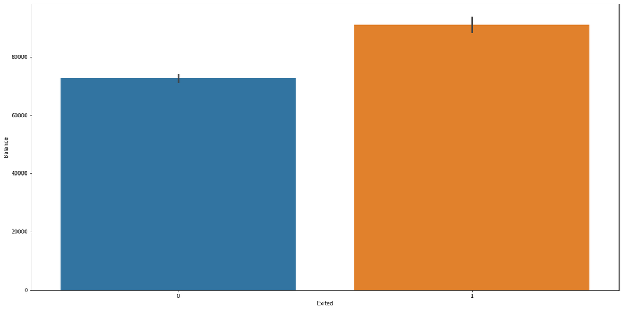

```python
plt.figure(figsize=(20,10))
sns.barplot(x=data['Exited'],y=data['Balance'])
```

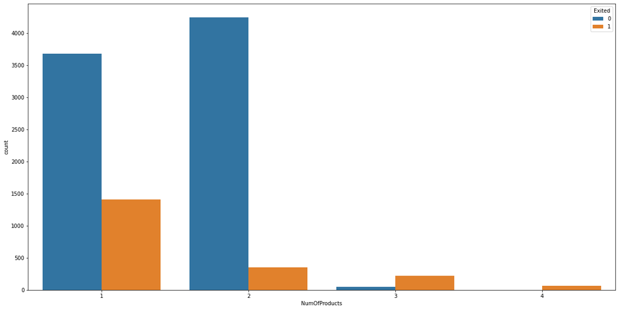

```python
plt.figure(figsize=(20,10))
sns.countplot(x=data['NumOfProducts'],hue=data['Exited'])
```

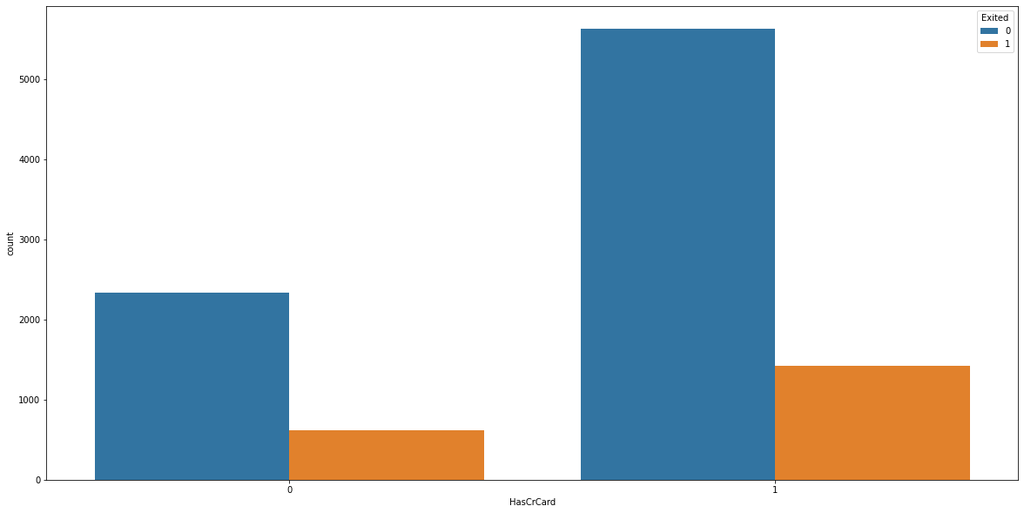

```python
plt.figure(figsize=(20,10))
sns.countplot(x=data['HasCrCard'],hue=data['Exited'])
```

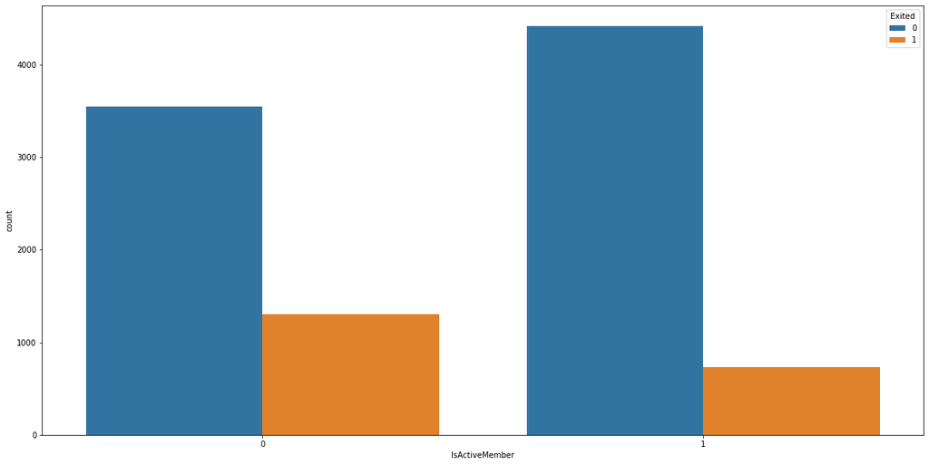

```python
plt.figure(figsize=(20,10))
sns.countplot(x=data['IsActiveMember'],hue=data['Exited'])
```

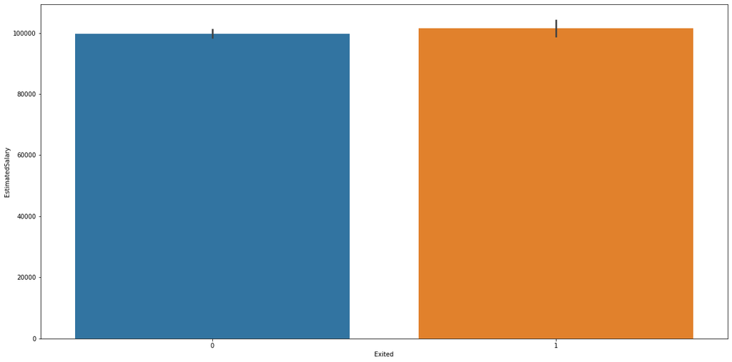

```python
plt.figure(figsize=(20,10))
sns.barplot(x=data['Exited'],y=data['EstimatedSalary'])
```

### **4. Distinguish the feature and target set and divide the data set into training and test sets**

```python
dum_df = pd.get_dummies(data=data, columns=['Geography','Gender'])
dum_df
```

|  | CreditScore | Age | Tenure | Balance | NumOfProducts | HasCrCard | IsActiveMember | EstimatedSalary | Exited | Geography_France | Geography_Germany | Geography_Spain | Gender_Female | Gender_Male |
| --- | --- | --- | --- | --- | --- | --- | --- | --- | --- | --- | --- | --- | --- | --- |
| 0 | 619 | 42 | 2 | 0.0000 | 1 | 1 | 1 | 101,348.8800 | 1 | 1 | 0 | 0 | 1 | 0 |
| 1 | 608 | 41 | 1 | 83,807.8600 | 1 | 0 | 1 | 112,542.5800 | 0 | 0 | 0 | 1 | 1 | 0 |
| 2 | 502 | 42 | 8 | 159,660.8000 | 3 | 1 | 0 | 113,931.5700 | 1 | 1 | 0 | 0 | 1 | 0 |
| 3 | 699 | 39 | 1 | 0.0000 | 2 | 0 | 0 | 93,826.6300 | 0 | 1 | 0 | 0 | 1 | 0 |
| 4 | 850 | 43 | 2 | 125,510.8200 | 1 | 1 | 1 | 79,084.1000 | 0 | 0 | 0 | 1 | 1 | 0 |
| ... | ... | ... | ... | ... | ... | ... | ... | ... | ... | ... | ... | ... | ... | ... |
| 9995 | 771 | 39 | 5 | 0.0000 | 2 | 1 | 0 | 96,270.6400 | 0 | 1 | 0 | 0 | 0 | 1 |
| 9996 | 516 | 35 | 10 | 57,369.6100 | 1 | 1 | 1 | 101,699.7700 | 0 | 1 | 0 | 0 | 0 | 1 |
| 9997 | 709 | 36 | 7 | 0.0000 | 1 | 0 | 1 | 42,085.5800 | 1 | 1 | 0 | 0 | 1 | 0 |
| 9998 | 772 | 42 | 3 | 75,075.3100 | 2 | 1 | 0 | 92,888.5200 | 1 | 0 | 1 | 0 | 0 | 1 |
| 9999 | 792 | 28 | 4 | 130,142.7900 | 1 | 1 | 0 | 38,190.7800 | 0 | 1 | 0 | 0 | 1 | 0 |

10000 rows × 14 columns

```python
dum_df['Exited'].value_counts()
```

```
0    7963
1    2037
Name: Exited, dtype: int64
```

```python
y = np.ravel(dum_df['Exited'])
X = dum_df.drop('Exited',axis=1)
```

```python
X_train, X_test, y_train, y_test = train_test_split(X,y,test_size=0.3,random_state=100,stratify=y)
```

### **5. Normalize the train and test data**

```python
X_train.head()
```

|  | CreditScore | Age | Tenure | Balance | NumOfProducts | HasCrCard | IsActiveMember | EstimatedSalary | Geography_France | Geography_Germany | Geography_Spain | Gender_Female | Gender_Male |
| --- | --- | --- | --- | --- | --- | --- | --- | --- | --- | --- | --- | --- | --- |
| 1485 | 475 | 46 | 10 | 0.0000 | 2 | 0 | 0 | 122,953.0000 | 1 | 0 | 0 | 1 | 0 |
| 8462 | 817 | 59 | 1 | 118,962.5800 | 1 | 1 | 1 | 120,819.5800 | 1 | 0 | 0 | 0 | 1 |
| 1025 | 582 | 32 | 4 | 0.0000 | 2 | 1 | 0 | 59,668.8100 | 1 | 0 | 0 | 1 | 0 |
| 1880 | 589 | 36 | 9 | 140,355.5600 | 2 | 1 | 0 | 136,329.9600 | 0 | 1 | 0 | 1 | 0 |
| 6245 | 591 | 39 | 8 | 0.0000 | 2 | 0 | 0 | 42,392.2400 | 0 | 0 | 1 | 0 | 1 |

```python
scaler = StandardScaler().fit(X_train)
X_train = scaler.transform(X_train)
X_test = scaler.transform(X_test)
```

```python
X_train[0:5]
```

```
array([[-1.82560073e+00,  6.66992761e-01,  1.72252211e+00,
        -1.22873174e+00,  8.06375500e-01, -1.54219920e+00,
        -1.03548640e+00,  3.99998596e-01,  9.94017892e-01,
        -5.81749192e-01, -5.68332053e-01,  1.09728311e+00,
        -1.09728311e+00],
       [ 1.71543517e+00,  1.90599703e+00, -1.39172035e+00,
         6.75835915e-01, -9.00497346e-01,  6.48424664e-01,
         9.65729726e-01,  3.62797114e-01,  9.94017892e-01,
        -5.81749192e-01, -5.68332053e-01, -9.11341831e-01,
         9.11341831e-01],
       [-7.17732774e-01, -6.67319531e-01, -3.53639533e-01,
        -1.22873174e+00,  8.06375500e-01,  6.48424664e-01,
        -1.03548640e+00, -7.03518599e-01,  9.94017892e-01,
        -5.81749192e-01, -5.68332053e-01,  1.09728311e+00,
        -1.09728311e+00],
       [-6.45255431e-01, -2.86087448e-01,  1.37649517e+00,
         1.01833334e+00,  8.06375500e-01,  6.48424664e-01,
        -1.03548640e+00,  6.33259153e-01, -1.00601811e+00,
         1.71895383e+00, -5.68332053e-01,  1.09728311e+00,
        -1.09728311e+00],
       [-6.24547619e-01, -1.63385179e-04,  1.03046823e+00,
        -1.22873174e+00,  8.06375500e-01, -1.54219920e+00,
        -1.03548640e+00, -1.00477855e+00, -1.00601811e+00,
        -5.81749192e-01,  1.75953475e+00, -9.11341831e-01,
         9.11341831e-01]])
```

### **6. Initialize & build the model. Identify the points of improvement and implement the same.**

### **7. Predict the results using 0.5 as a threshold**

### **8. Print the Accuracy score and confusion matrix**

```python
model_1 = Sequential()

# Define model architecture
model_1.add(Dense(13, activation='tanh', input_shape=(13,)))
model_1.add(Dense(50, activation ='relu'))
model_1.add(Dense(1, activation='sigmoid'))

model_1.compile(loss='binary_crossentropy',metrics=['accuracy'])

model_1.fit(X_train, y_train, verbose=1)
```

```
<tensorflow.python.keras.callbacks.History at 0x7f4495d89278>
```

```python
model_1.summary()
```

```
Model: "sequential_4"
_________________________________________________________________
Layer (type)                 Output Shape              Param #
=================================================================
dense_21 (Dense)             (None, 13)                182
_________________________________________________________________
dense_22 (Dense)             (None, 50)                700
_________________________________________________________________
dense_23 (Dense)             (None, 1)                 51
=================================================================
Total params: 933
Trainable params: 933
Non-trainable params: 0
_________________________________________________________________
```

```python
y_pred = np.round(model_1.predict(X_test))

loss, acc = model_1.evaluate(X_train, y_train, verbose=0)
print('Train Accuracy: ',acc)

loss, acc = model_1.evaluate(X_test, y_test, verbose=0)
print('Test Accuracy:',acc)
```

```
Train Accuracy:  0.8080000281333923
Test Accuracy: 0.8006666898727417
```

```python
print(pd.DataFrame(metrics.confusion_matrix(y_test, y_pred, labels=[0 ,1]),index=['true:Not Exited', 'true:Exited'], columns=['pred:Not Exited', 'pred:Exited']))
```

```
                 pred:Not Exited  pred:Exited
true:Not Exited             2350           39
true:Exited                  559           52
```

```python
cr=metrics.classification_report(y_test,y_pred)
print(cr)
```

```
              precision    recall  f1-score   support

           0       0.81      0.98      0.89      2389
           1       0.57      0.09      0.15       611

    accuracy                           0.80      3000
   macro avg       0.69      0.53      0.52      3000
weighted avg       0.76      0.80      0.74      3000
```

*Now Optimizing as Model 2*

```python
model_2 = Sequential()

# Define model architecture
model_2.add(Dense(100, activation='tanh', input_shape=(13,)))
model_2.add(Dense(100, activation ='tanh'))
model_2.add(Dense(100, activation ='elu'))
model_2.add(Dense(100, activation ='relu'))
model_2.add(Dense(50, activation ='relu'))
model_2.add(Dense(1, activation='sigmoid'))

model_2.compile(loss='binary_crossentropy',
               optimizer='nadam',
               metrics=['accuracy'])
model_2.fit(X_train, y_train, epochs=10, batch_size=700, verbose=1)
```

```
<tensorflow.python.keras.callbacks.History at 0x7f44943c0748>
```

```python
y_pred = np.round(model_2.predict(X_test))
```

```python
y_pred[0:10]
```

```
array([[0.],
       [0.],
       [0.],
       [0.],
       [1.],
       [0.],
       [0.],
       [0.],
       [0.],
       [0.]], dtype=float32)
```

```python
loss, acc = model2.evaluate(X_train, y_train, verbose=0)
print('Train Accuracy:',acc)

loss, acc = model2.evaluate(X_test, y_test, verbose=0)
print('Test Accuracy: ',acc)
```

[output not shown]

```python
print(pd.DataFrame(metrics.confusion_matrix(y_test, y_pred, labels=[0 ,1]), index=['true:Not Exited', 'true:Exited'], columns=['pred:Not Exited', 'pred:Exited']))
```

```
                 pred:Not Exited  pred:Exited
true:Not Exited             2326           63
true:Exited                  382          229
```

```python
cr=metrics.classification_report(y_test,y_pred)
print(cr)
```

```
              precision    recall  f1-score   support

           0       0.86      0.97      0.91      2389
           1       0.78      0.37      0.51       611

    accuracy                           0.85      3000
   macro avg       0.82      0.67      0.71      3000
weighted avg       0.84      0.85      0.83      3000
```

*Now Optimizing as Model 3*

```python
model_3 = Sequential()

# Define model architecture
model_3.add(Dense(100, activation='tanh', input_shape=(13,)))
model_3.add(Dense(100, activation ='tanh'))
model_3.add(Dense(100, activation ='elu'))
model_3.add(Dense(100, activation ='relu'))
model_3.add(Dense(50, activation ='relu'))
model_3.add(Dense(1, activation='sigmoid'))

model_3.compile(loss='binary_crossentropy',
               optimizer='nadam',
               metrics=['accuracy'])
model_3.fit(X_train, y_train, epochs=10, batch_size=700, verbose=1)
```

```
<tensorflow.python.keras.callbacks.History at 0x7f44930eeb70>
```

```python
y_pred = np.round(model_3.predict(X_test))
```

```python
loss, acc = model_3.evaluate(X_train, y_train, verbose=0)
print('Train Accuracy:',acc)

loss, acc = model_3.evaluate(X_test, y_test, verbose=0)
print('Test Accuracy:',acc)
```

```
Train Accuracy: 0.866428554058075
Test Accuracy: 0.8526666760444641
```

```python
cr=metrics.classification_report(y_test,y_pred)
print(cr)
```

```
              precision    recall  f1-score   support

           0       0.85      0.98      0.91      2389
           1       0.83      0.35      0.49       611

    accuracy                           0.85      3000
   macro avg       0.84      0.66      0.70      3000
weighted avg       0.85      0.85      0.83      3000
```